# Reproducible Workflows for Ecology Research

10/11/2018

## Why bother?

- For future you
- For collaborators
- Because you want people to use and appreciate your data and code
- Because it is encouraged or required by a journal

## Organizing Projects

## Directory Structure

At minimum:

- data
- analysis
- output
- readme.md

## Directory Structure

I like:

- raw_data
- wrangling
- cleaned_data
- analysis
- figs
- output
- manuscript

## Do all data manipulation programatically

Even things like re-formatting data. Why?

- More reproducible
- Easy to make errors editing data by hand (E.g. Excel suddenly things your column is dates)
- Consider making raw data files read-only to help you resist the temptation!

## File Naming

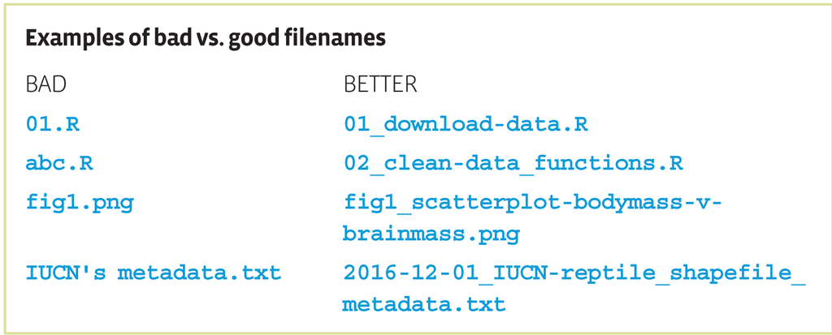

- Considering alphabetical ordering of numbers
  - Numbering (`01_wrangle-data.Rmd`, `02_analyze-data.Rmd`)
  - Dates (`2018-10-12_ERGO-data.csv`)

## Tools to help you get organized

Projects in RStudio:

- Automatically set the working directory
- Easy to switch between projects
- Integrates well with version control

## Tools to help you get organized

The `workflowr` 📦:

- creates directory structure with readme and licence
- sets up version control
- makes everything into a website
- nifty, but probably overkill

## Tools to help you get organized

R for Data Science:

- (r4ds.had.co.nz)
- great resource for learning more about data wrangling in R
- wean yourself off of editing raw data by hand

## Programming

## Write Functions

If you find yourself copying and pasting the same code a lot, consider writing a function.

"But functions are scary!"

**R Studio tip**: '*Extract Function*'

## Make a Package?

If you find yourself writing a lot of functions, condiser making a package.

- "But packages are even scarrier!"
- `usethis` 📦 and RStudio make it relatively easy.
- You can totally learn to do this!
- Publishing a package along with a paper means that paper gets cited whenever somoene uses your package (ideally).

## Code portability

- Use relative paths ("/img/puppy.jpg" NOT "/Users/Eric/Documents/ERGO/img/puppy.jpg")
- Better yet, use the `here` 📦

```r
library(here)
read_file(here("data", "sometext.txt"))
```

```
## [1] "Hi ERGO!"
```

- `packrat` 📦 if updates to packages might break your code

## Reproducible Reports

## RMarkdown

- Allows you to combine prose (markdown), code, and code output in one document
- Great way to keep an analysis "lab notebook"
- Creates nifty looking reports in HTML, pdf, Word
- I made this with it!
- Not essential to reproducible code, IMO

## Version Control

## Git

- Like "track changes" on steroids
- Creates a "repository" for your project
- When you make changes, you "commit" them, commenting on what the changes are.
- You can also try a different approach in a new "branch"
- If all you're worried about is backups, **not worth it!**

## GitHub

- Hosts git repositories online
- Students can get an account that gives private repositories
- Good for backing-up, sharing, and collaborating on projects
- Git and GitHub are integrated in RStudio, so you (usually) don't have to do anything from the command line

## Tools to help with Git/GitHub

- [happygitwithr.com](http://happygitwithr.com/)
- `usethis` 📦 has `use_git()` and `use_github()`

## Archiving

## Archiving Data and Analyses

- Some journals now require that you archive your data in some way alongside a manuscript submission
- E.g. Mendeley Data, Dryad, Open Science Framework, Zenodo
- Gives your data and analyses a citeable DOI
- If you follow reproducibility advice, this step is relatively painless.